# A quick introduction to R and Quarto from within RStudio

Tiago A. Marques

2026-09-20

## Objective

This presentation provides an introduction to R and RStudio.

It covers topics to be used in courses that require such introduction, including TAM’s courses Ecologia Numérica and Modelação Ecológica at FCUL.

Therefore you are most likely seeing it a class being delivered, unless you are working on your own.

## Independent use

This document could be also used as an introduction to the self-paced learning github repository hosted at https://github.com/TiagoAMarques/AnIntro2RTutorial

The tutorial has a landing webpage (and hence looks a bit friendlier) here:

https://tiagoamarques.github.io/AnIntro2RTutorial/

This document is also available online at RPubs at

https://rpubs.com/talomarques/AnIntroToRandRStudio

This presentation was created using [Quarto](https://quarto.org/) and [revealjs](https://quarto.org/). Want to try yourself. Check its amazing capabilities [here](https://quarto.org/docs/presentations/revealjs/demo/#/title-slide)

## Obtaining the material

You can get all the material by downloading and unziping the [github repository](https://tiagoamarques.github.io/AnIntro2RTutorial/) contents. See image below: press the button at the end of the red arrow, then that of the blue arrow, and finally unzip the material into a folder of your choice.

[figure not shown]

## Learning goals

- Obtain a working knowledge about the R software and environment, to be able to implement basic data analysis
- Integration of R and RStudio, an helpful R interface, via a short introduction to R and RStudio followed by a hands on assisted tutorial

## The R environment

- R is both a programming language and an environment for statistical computation
- R is free open source software
- Created in 1995 by Ross Ihaka and Robert Gentleman, Department of Statistics of the University of Auckland
- gets its name from another famous programming language for data analysis, S
- Project run by the “R Core Development Team”
- Software and many resources available at the [r-project.org/](http://www.r-project.org)

I am using version 4.3.1 (2023-06-16) (those guys are fast…this will probably be outdated!)

## R: a selected timeline

[figure not shown]

In Giorgi et al. 2022 The R Language: An Engine for Bioinformatics and Data Science Life 12: 648 DOI: [10.3390/life12050648](https://www.mdpi.com/2075-1729/12/5/648)

## The R base + packages

- R base installation comes with a number of libraries which provide access to a large number of commonly used features (e.g. linear models, survival analysis, basic statistical distributions, etc)
- One of R’s key strengths comes from the fact that many more packages are available online, under constant increase

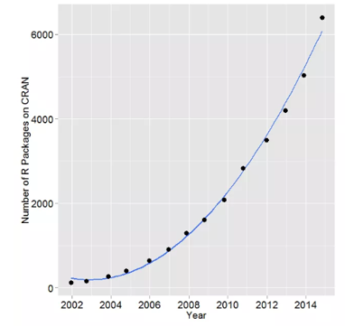

[image source at r4stats.com](http://r4stats.com/articles/popularity/) - [different sources](https://medium.com/@tomazkastrun/r-package-updates-and-release-dates-statistics-and-another-rise-of-r-language-5125faa80eb1) provide different numbers, but overall patters are the same

## The R environment

- R was traditionally accessed solely via the command line, making the learning curve rather steep for beginners

[figure not shown]

- Here we focus on Rstudio, a program to interface with R, making many of the most common tasks simpler. Let’s open Rstudio shall we?

[Download RStudio here](https://posit.co/blog/rstudio-2022-07-0-what-s-new/)

## RStudio

- (as R) Free and open source
- An integrated development environment for data analysis
- Simplifies the user interaction with R
- In a single application you have access to a number of windows containing the code, the command line, the figures, the help, a windows explorer, etc.

[figure not shown]

## 4 windows, 4 ways to interact with R

[figure not shown]

## The code and plots tabs

[figure not shown]

## The environment tab

[figure not shown]

## The packages tab

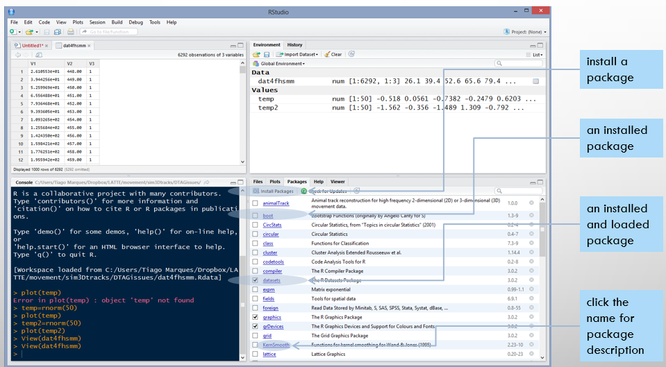

## History and “windows explorer” tabs

[figure not shown]

## The help tab

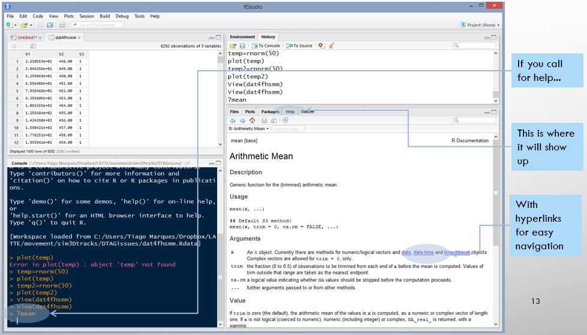

## Aditional online resources

R HAS AMAZING (ENDLESS) ONLINE RESOURCES

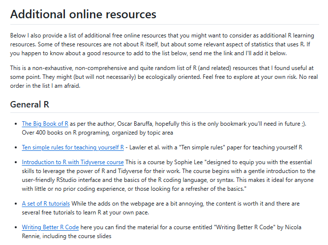

[Check the landing page at my AnIntro2RTutorial github repos](https://github.com/TiagoAMarques/AnIntro2RTutorial)

## Quarto and Dynamic Reports

[figure not shown]

## Creating a dynamic report I

Let us create a dynamic report from scratch in Quarto via RStudio

[figure not shown]

## Set Title and author

Let us create a dynamic report from scratch in Quarto via RStudio

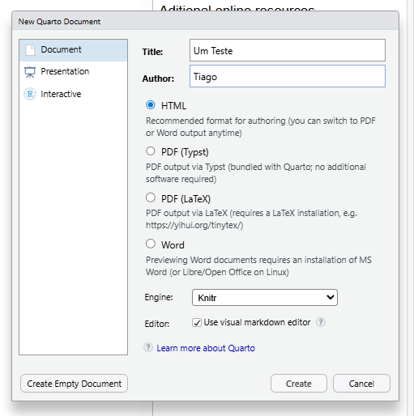

## Almost there

This is what you should be seeing. Check your title and name are there.

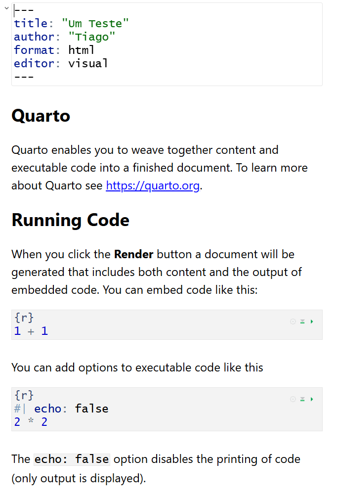

## Compile the .qmd

[figure not shown]

## If you run into issues

Regarding “latin” characters showing, like say “é”, “õ” and â”

[figure not shown]

## Et voilá

Your first quarto dynamic report is ready

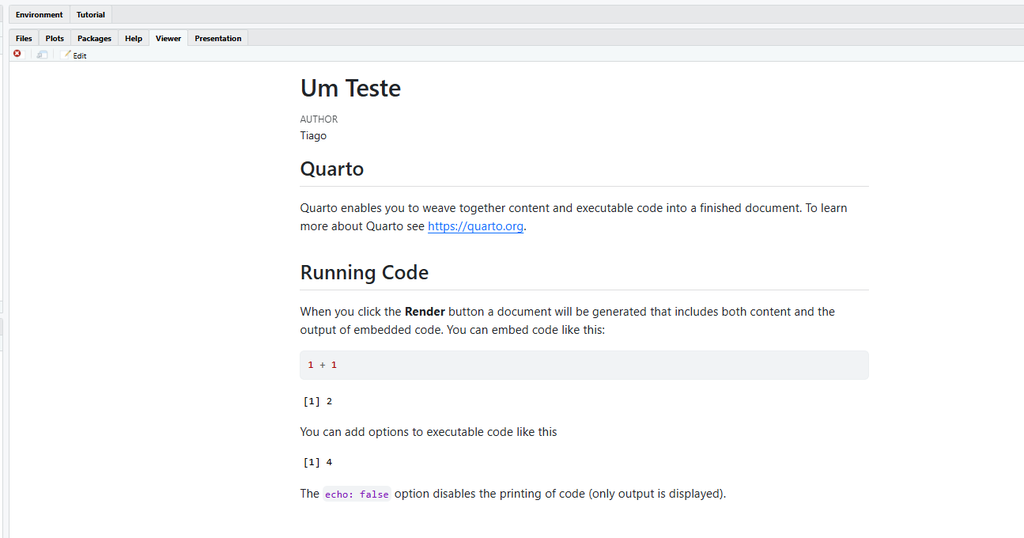

## If you want it in the viewer pane

Unless you have customized RStudio to do otherwise, the html appears in a new window. To have it in the viewer pane, change the options under `Tools| Global Options`

## Possible outputs

[figure not shown]

## Experiment with the .qmd file

- Try to insert a new bit of code with `Code|insert chunck` (shortcut `Ctrl+Al+I`)
- Change a chunck’s options (e.g. `eval`, `echo`, etc) from `TRUE` to `FALSE` and see what whappens to the output
- Try to use dynamic numbers like this one: -0.2737723 printing the mean value of 5 random Gaussian numbers. For that you need to use something like `? mean(rnorm(5))` (note: replace the “?” with the leter “r” so that it knows you want to run r code).
- For more, check e.g. the [quarto cheat sheet](https://rstudio.github.io/cheatsheets/quarto.pdf)

## Warning: command line vs .Rmd

[figure not shown]

- When you run some code within a .qmd, it is only run in the .qmd
- When you run some code in the command line, it is only run in the command line
- Therefore, reading the data in the command line does NOT mean it will be available for a dynamic report, and vice versa!

## Tips and Tricks

- It is much safer to compile the entire document than to run code chunks separately
- A .qmd is not a usual script, it has both code and text. The result is a dynamic document, with Text, Code, and Ooutputs of the code
- The code must go always, always, always inside a code chunck!
- Comments to the code can also be within code chunks (preceded by “#” – the hash symbol).

```r
# EXAMPLE: this would be a comment
# run the next lines of code the result is 11
A<-3;B<-8;A+B
```

```
[1] 11
```

## Useful Quarto web resources

- An quarto template with lots of tips and trick made just for YOU [here](https://github.com/TiagoAMarques/template_4_quarto_report)
- About R Markdown, the official site [here](https://rmarkdown.rstudio.com/)
- The online free [book](https://bookdown.org/yihui/rmarkdown)
- Chapter 27 on RMarkdown from the fRee online book: R FOR DATA SCIENCE [here](https://r4ds.had.co.nz/r-markdown.html)

-how to write a book with markdown, with several VERY USEFUL BOOK examples available for free [here](https://bookdown.org/)

BE PROACTIVE: EXPLORE RESOURCES

## And finally…

Open the hands on R tutorial (“TAMsIntro2RviaRStudioTutorial.pdf”) and work through it

[figure not shown]

## If you are seeing this slide

It is because you either:

1. have completed the tutorial (well done you, keep it going!)
2. are being shown the slide in class by me/someone (and hence might do the tutorial next, go for it!)
3. are not following the rules if working alone (shame on you ;), but hey, rules are meant to be broken, YOLO.

Next couple of slides are about learning more about R on your own. Besides all the stuff at the landing page of my github repository here:

https://github.com/TiagoAMarques/AnIntro2RTutorial

You can try a couple of things

## Teach yourself

A great place to start [Ten simple rules for teaching yourself R](https://www.dropbox.com/s/6j5byl93z54hcpw/journal.pcbi.1010372.pdf?dl=0)

[figure not shown]

## Get a (virtual) R Tutor

You can find one within the [swirl R package](https://swirlstats.com/): try it out!

[figure not shown]

## And now, off you go!

The path to R mastery is winding, but the reward is worth it…

[figure not shown]